# Assignment #5

Janelle Morano

5/4/2022

## 1. Hierarchical Clustering to Explore Partitioning

Use stream reach properties to determine whether brook trout are likely to reside within a given stream reach

```r
data <- read.csv("/Users/janellemorano/Git/Reference-R-scripts/Envtl-Multivariate-Stats/data/Maryland.Trout.csv", header = TRUE)
```

1. Calculate a distance matrix between scale reach properties (X.Ag, LOG_RD,TEMP_FLD,RIFQUAL,DO_FLD)

```r
# function to standardize
scale2 <- function(x) {
  x <- (x- mean(x))/sd(x)
  return(x)
}

# Standardize each reach property in the dataset
# MARGIN = 2 applies the function scale2 to each column
scale.covariates <- apply(data[,3:7], MARGIN = 2, FUN=scale2)
# head(scale.covariates)

d <- dist(scale.covariates) # will be a lower triangular matrix of distances between each of 7 variables
```

2. Using hclust() function, generate and plot 4 different dendrograms based on the distance matrix, using four different methods for clustering groups with more than one member (“centroid”, “single linkage”, “complete linkage”, and “average”).

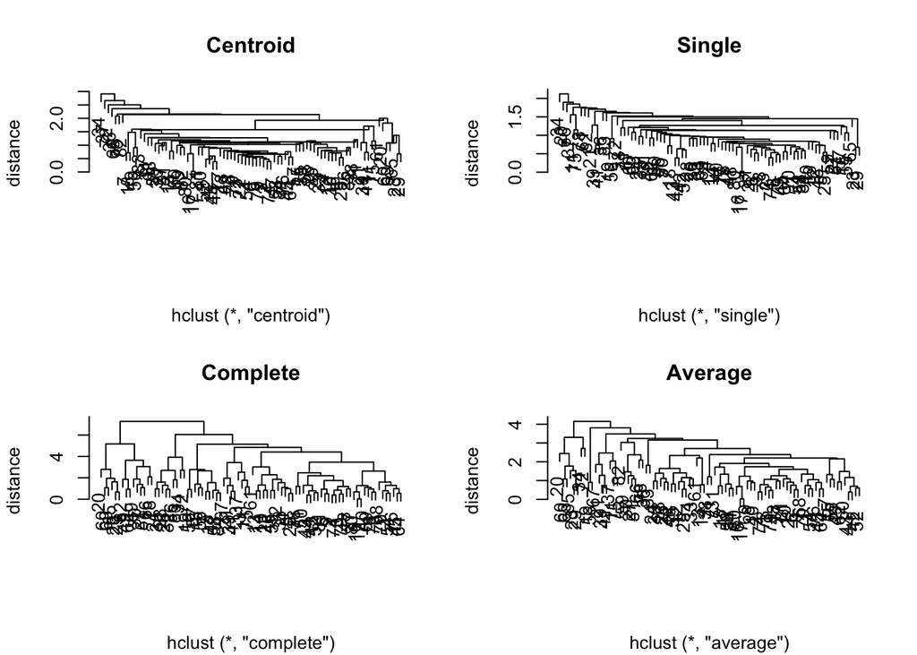

```r
h.centroid <- hclust(d, "centroid")
h.single <- hclust(d, "single")
h.complete <- hclust(d, "complete")
h.average <- hclust(d, "average")

par(mfrow = c(2,2))
plot(h.centroid, main="Centroid", xlab="", ylab="distance")
plot(h.single, main="Single", xlab="", ylab="distance")
plot(h.complete, main="Complete", xlab="", ylab="distance")
plot(h.average, main="Average", xlab="", ylab="distance")
```

```r
par(mfrow = c(1,1))
```

4. Using the complete-linkage dendrogram and the cutree function(), cut the tree to allocate different observations to two different clusters, #row id

```r
cluster <- cutree(h.complete, k = 2) #row id
obs <- data.frame(cbind(cluster, scale.covariates, data$bkt))

# rename
library(dplyr)
obs <- obs %>%
  rename(bkt = V7)
```

5. Report the mean across 2 clusters

```r
cluster1 <- obs %>%
  filter(cluster == 1)

cluster2 <- obs %>%
  filter(cluster == 2)

#mean of variables for both clusters
cluster1.mean <- apply(cluster1[,2:6], MARGIN = 2, FUN = mean)
cluster2.mean <- apply(cluster2[,2:6], MARGIN = 2, FUN = mean)
mean.cluster <- rbind(cluster1.mean, cluster2.mean)

# print mean of clusters
print(mean.cluster)
```

```
##                      X.Ag  RIFFQUAL      LOG_RD   TEMP_FLD     DO_FLD
## cluster1.mean -0.07662015  0.315446 -0.01391697 -0.1787079  0.2271562
## cluster2.mean  0.35245271 -1.451052  0.06401808  0.8220563 -1.0449184
```

e, cont.) 2x2 contigency table of how trout presence/absence is distributed (for each cluster, how many have trout, how many don’t)

```r
table(cluster = obs$cluster, trout = obs$bkt)
```

```
##        trout
## cluster  0  1
##       1 28 41
##       2 14  1
```

## What can you conclude from these results?

## 2. K-Means Clustering to Explore Partitioning

6. run kmeans for groups of k=1:10

```r
kmeans.list <- vector(mode = "list", length = 10)
for (i in 1:10) {
  kmeans.list[[i]] <- kmeans(scale.covariates, centers= i, nstart = 10)
}
```

7. Plot the variance explained by the clusters against the number of clusters for each of the different values of K tested.

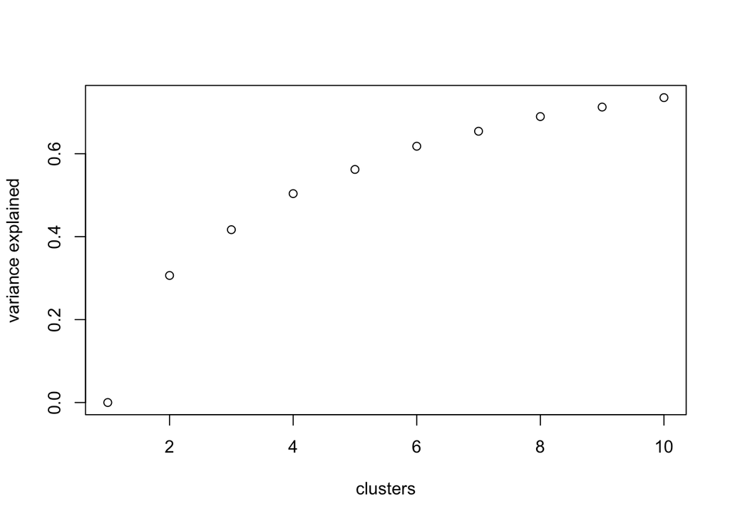

```r
evar <- c()
for (i in 1:10) {
  evar[i] <- kmeans.list[[i]]$betweenss/kmeans.list[[i]]$totss
}
clustevar <- cbind(rep(1:10), evar)
plot(clustevar[,1], clustevar[,2], xlab="clusters", ylab="variance explained")
```

8. show how the mean characteristics of reaches differ across the two clusters. Also similar to (e) above, present a table that shows how trout presence/absence is distributed across the clusters. What can you conclude from these results, and how do they compare to the results using the hierarchical clustering approach?

```r
kmeans2 <- data.frame(cbind(kmeans.list[[2]]$cluster, scale.covariates, data$bkt))
kmeans2 <- kmeans2 %>%
  rename(cluster = V1,
         bkt = V7)
kmeans2.clst1 <- kmeans2 %>%
  filter(cluster == 1)
kmeans2.clst2 <- kmeans2 %>%
  filter(cluster == 2)

#mean of variables for both clusters
kmeans2.clst1.mean <- apply(kmeans2.clst1[,2:6], MARGIN = 2, FUN = mean)
kmeans2.clst2.mean <- apply(kmeans2.clst2[,2:6], MARGIN = 2, FUN = mean)
kmeans2.means <- rbind(kmeans2.clst1.mean, kmeans2.clst2.mean)

# print mean of clusters
print(kmeans2.means)
```

```
##                          X.Ag   RIFFQUAL      LOG_RD   TEMP_FLD     DO_FLD
## kmeans2.clst1.mean -0.4458783  0.4390156  0.09121181 -0.4888431  0.3991890
## kmeans2.clst2.mean  0.8456312 -0.8326158 -0.17298792  0.9271163 -0.7570825
```

```r
# contingency table
table(cluster = kmeans2$cluster, trout = kmeans2$bkt)
```

```
##        trout
## cluster  0  1
##       1 21 34
##       2 21  8
```